# ADA Final Project

#### Let’s make sure we have enough cases in each exposure/outcome category, we are adding other potential variables we will use. If any strata have <10 counts, we may need to regroup.

```r
# Create a contingency table to check counts in each strata
table(chs_data_analysis$non_specific_psychological_distress, chs_data_analysis$housing_instability,chs_data_analysis$age_group)
```

```
## , ,  = 18-24
##
##
##         No  Yes
##   No   563   62
##   Yes   36    8
##
## , ,  = 25-29
##
##
##         No  Yes
##   No   547  115
##   Yes   38   16
##
## , ,  = 30-44
##
##
##         No  Yes
##   No  1858  413
##   Yes   90   49
##
## , ,  = 45-64
##
##
##         No  Yes
##   No  2286  463
##   Yes  107   64
##
## , ,  = 65-74
##
##
##         No  Yes
##   No  1046  105
##   Yes   41   12
##
## , ,  = 75+
##
##
##         No  Yes
##   No   609   38
##   Yes   33    5
```

### Combining Age Groups

```r
chs_data_analysis <- chs_data_analysis %>%
mutate(
  age_group_combined = case_when(
    age_group %in% c("18-24", "25-29") ~ "18-29",
    age_group == "30-44" ~ "30-44",
    age_group == "45-64" ~ "45-64",
    age_group %in% c("65-74", "75+") ~ "65+",
    is.na(age_group) ~ NA_character_  # Explicitly handle NAs
  ),
  age_group_combined = factor(
    age_group_combined,
    levels = c("18-29", "30-44", "45-64", "65+")
  )
)%>%
  select(-age_group) %>%               # Remove the original age_group column
  rename(age_group = age_group_combined) # Rename age_group_combined to age_group
```

**Interpretation**

We have some low counts under the age groups of 18-24 and above 75 years which will affect the accurancy of our models. Hence, we will combine the ages to have only 4 groups as follows (18-29, 30-44,45-64 and 65+).

```r
# Create Table 1 stratified by housing_instability and sex

table1(
  ~ age_group + housing_instability + employment_status + income_level + health_insurance_status |non_specific_psychological_distress
    , data = chs_data_analysis)
```

|  | No (N=8105) | Yes (N=499) | Overall (N=8604) |
| --- | --- | --- | --- |
| age_group |  |  |  |
| 18-29 | 1287 (15.9%) | 98 (19.6%) | 1385 (16.1%) |
| 30-44 | 2271 (28.0%) | 139 (27.9%) | 2410 (28.0%) |
| 45-64 | 2749 (33.9%) | 171 (34.3%) | 2920 (33.9%) |
| 65+ | 1798 (22.2%) | 91 (18.2%) | 1889 (22.0%) |
| housing_instability |  |  |  |
| No | 6909 (85.2%) | 345 (69.1%) | 7254 (84.3%) |
| Yes | 1196 (14.8%) | 154 (30.9%) | 1350 (15.7%) |
| employment_status |  |  |  |
| Employed | 4497 (55.5%) | 185 (37.1%) | 4682 (54.4%) |
| Unemployed | 1053 (13.0%) | 91 (18.2%) | 1144 (13.3%) |
| Not in labor force | 2555 (31.5%) | 223 (44.7%) | 2778 (32.3%) |
| income_level |  |  |  |
| Low Income | 3392 (41.9%) | 297 (59.5%) | 3689 (42.9%) |
| Moderate Income | 1434 (17.7%) | 68 (13.6%) | 1502 (17.5%) |
| High Income | 3279 (40.5%) | 134 (26.9%) | 3413 (39.7%) |
| health_insurance_status |  |  |  |
| No | 861 (10.6%) | 51 (10.2%) | 912 (10.6%) |
| Yes | 7244 (89.4%) | 448 (89.8%) | 7692 (89.4%) |

### Descriptive Analysis

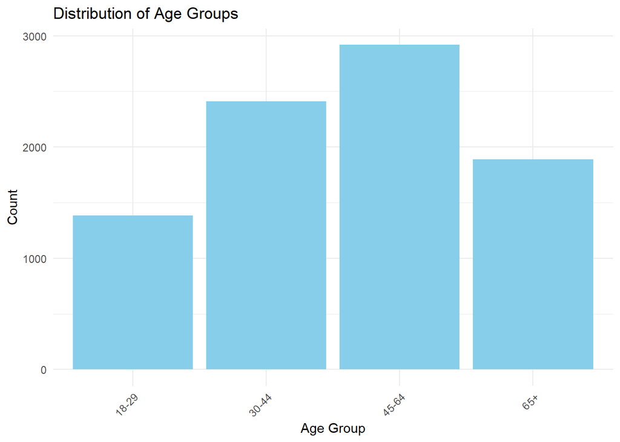

```r
library(ggplot2)

# Bar chart for age groups
ggplot(chs_data_analysis, aes(x = age_group)) +
  geom_bar(fill = "skyblue") +
  labs(title = "Distribution of Age Groups", x = "Age Group", y = "Count") +
  theme_minimal() +
  theme(axis.text.x = element_text(angle = 45, hjust = 1))
```

### Binomial Logistic Regression

```r
model1<- glm(non_specific_psychological_distress ~ housing_instability, data=chs_data_analysis, family="binomial")
summary(model1) # get log results
```

```
##
## Call:
## glm(formula = non_specific_psychological_distress ~ housing_instability,
##     family = "binomial", data = chs_data_analysis)
##
## Coefficients:
##                        Estimate Std. Error z value Pr(>|z|)
## (Intercept)            -2.99704    0.05516 -54.332   <2e-16 ***
## housing_instabilityYes  0.94725    0.10185   9.301   <2e-16 ***
## ---
## Signif. codes:  0 '***' 0.001 '**' 0.01 '*' 0.05 '.' 0.1 ' ' 1
##
## (Dispersion parameter for binomial family taken to be 1)
##
##     Null deviance: 3810.2  on 8603  degrees of freedom
## Residual deviance: 3733.3  on 8602  degrees of freedom
## AIC: 3737.3
##
## Number of Fisher Scoring iterations: 5
```

```r
myoutput1 <- odds.n.ends(model1) # get OR results (and more!)
myoutput1
```

```
## $`Logistic regression model significance`
## Chi-squared        d.f.           p
##        76.9           1       <.001
##
## $`Contingency tables (model fit): frequency predicted`
##                 Number observed
## Number predicted    1    0  Sum
##              1      0    0    0
##              0    499 8105 8604
##              Sum  499 8105 8604
##
## $`Count R-squared (model fit): percent correctly predicted`
## [1] 94.20037
##
## $`Model sensitivity`
## [1] 0
##
## $`Model specificity`
## [1] 1
##
## $`Predictor odds ratios and 95% CI`
##                                OR      2.5 %     97.5 %
## (Intercept)            0.04993487 0.04473679 0.05554037
## housing_instabilityYes 2.57860983 2.10738712 3.14230372
```

**Based model Interpretation:**

The odds of experiencing non-specific psychological distress among individuals with housing instability are **2.58 times higher** compared to those without housing instability (OR = 2.58, 95% CI [2.11, 3.14]).

#### Adding and adjust for other covariates

```r
model2 <- glm(
  non_specific_psychological_distress ~ housing_instability + age_group + income_level + employment_status + health_insurance_status,
  family = binomial,
  data = chs_data_analysis
)
summary(model2)
```

```
##
## Call:
## glm(formula = non_specific_psychological_distress ~ housing_instability +
##     age_group + income_level + employment_status + health_insurance_status,
##     family = binomial, data = chs_data_analysis)
##
## Coefficients:
##                                     Estimate Std. Error z value Pr(>|z|)
## (Intercept)                          -3.1762     0.1985 -15.999  < 2e-16 ***
## housing_instabilityYes                0.8170     0.1084   7.534 4.93e-14 ***
## age_group30-44                       -0.1393     0.1400  -0.995 0.319736
## age_group45-64                       -0.2302     0.1335  -1.725 0.084555 .
## age_group65+                         -0.7644     0.1602  -4.771 1.83e-06 ***
## income_levelModerate Income          -0.4157     0.1406  -2.956 0.003116 **
## income_levelHigh Income              -0.4310     0.1148  -3.755 0.000174 ***
## employment_statusUnemployed           0.4931     0.1378   3.577 0.000347 ***
## employment_statusNot in labor force   0.8878     0.1166   7.613 2.69e-14 ***
## health_insurance_statusYes            0.3088     0.1581   1.953 0.050806 .
## ---
## Signif. codes:  0 '***' 0.001 '**' 0.01 '*' 0.05 '.' 0.1 ' ' 1
##
## (Dispersion parameter for binomial family taken to be 1)
##
##     Null deviance: 3810.2  on 8603  degrees of freedom
## Residual deviance: 3626.8  on 8594  degrees of freedom
## AIC: 3646.8
##
## Number of Fisher Scoring iterations: 6
```

```r
myoutput2 <-odds.n.ends(model2) # get OR results
myoutput2
```

```
## $`Logistic regression model significance`
## Chi-squared        d.f.           p
##     183.344           9       <.001
##
## $`Contingency tables (model fit): frequency predicted`
##                 Number observed
## Number predicted    1    0  Sum
##              1      0    0    0
##              0    499 8105 8604
##              Sum  499 8105 8604
##
## $`Count R-squared (model fit): percent correctly predicted`
## [1] 94.20037
##
## $`Model sensitivity`
## [1] 0
##
## $`Model specificity`
## [1] 1
##
## $`Predictor odds ratios and 95% CI`
##                                             OR      2.5 %     97.5 %
## (Intercept)                         0.04174253 0.02800569 0.06102436
## housing_instabilityYes              2.26367788 1.82676518 2.79516419
## age_group30-44                      0.86993892 0.66209576 1.14705620
## age_group45-64                      0.79434443 0.61281810 1.03473015
## age_group65+                        0.46562202 0.33991983 0.63741886
## income_levelModerate Income         0.65989903 0.49746148 0.86399676
## income_levelHigh Income             0.64984660 0.51778959 0.81232166
## employment_statusUnemployed         1.63731637 1.24540743 2.13901591
## employment_statusNot in labor force 2.42988754 1.93327996 3.05454810
## health_insurance_statusYes          1.36173985 1.00818760 1.87577695
```

#### **Interpretation: Model2 adjusting for other variables**

The odds of experiencing non-specific psychological distress among individuals with housing instability are 2.26 times higher compared to those without housing instability (OR = 2.26, 95% CI [1.83, 2.80]). Individuals aged 65 and older are 53% less likely to experience psychological distress compared to those aged 18–29 (OR = 0.47, 95% CI [0.34, 0.64]). Moderate-income and high-income earners are 34% less likely to experience psychological distress compared to low-income earners (Moderate Income: OR = 0.66, 95% CI [0.50, 0.86]; High Income: OR = 0.65, 95% CI [0.52, 0.81]). Unemployed individuals are 1.64 times more likely, and those not in the labor force are 2.43 times more likely to report psychological distress compared to those employed (Unemployed: OR = 1.64, 95% CI [1.25, 2.14]; Not in labor force: OR = 2.43, 95% CI [1.93, 3.05]).

#### Summarizing the results using a Forest plot

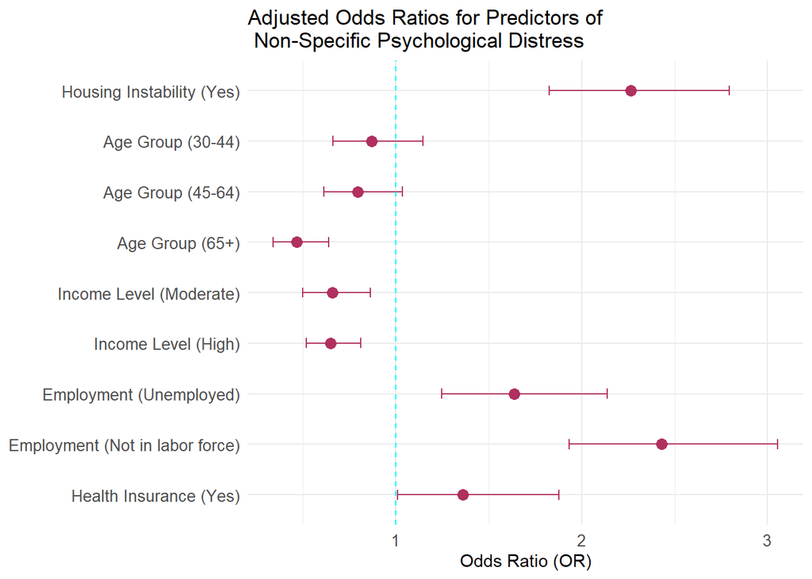

```r
# Load necessary library
library(ggplot2)

# Create a data frame with the data
data <- data.frame(
  Predictor = c(
    "Housing Instability (Yes)",
    "Age Group (30-44)",
    "Age Group (45-64)",
    "Age Group (65+)",
    "Income Level (Moderate)",
    "Income Level (High)",
    "Employment (Unemployed)",
    "Employment (Not in labor force)",
    "Health Insurance (Yes)"
  ),
  OR = c(
    2.2637, 0.8699, 0.7943, 0.4656, 0.6599, 0.6498, 1.6373, 2.4299, 1.3617
  ),
  Lower_CI = c(
    1.8268, 0.6621, 0.6128, 0.3399, 0.4975, 0.5178, 1.2454, 1.9333, 1.0082
  ),
  Upper_CI = c(
    2.7952, 1.1471, 1.0347, 0.6374, 0.8640, 0.8123, 2.1390, 3.0545, 1.8758
  )
)

# Reorder predictors for better visualization
data$Predictor <- factor(data$Predictor, levels = rev(data$Predictor))

# Create the forest plot
ggplot(data, aes(x = OR, y = Predictor)) +
  geom_point(color = "maroon", size = 3) +
  geom_errorbarh(aes(xmin = Lower_CI, xmax = Upper_CI), height = 0.2, color = "maroon") +
  geom_vline(xintercept = 1, linetype = "dashed", color = "cyan") +
  labs(
    title = "Adjusted Odds Ratios for Predictors of \n Non-Specific Psychological Distress",
    x = "Odds Ratio (OR)",
    y = ""
  ) +
  theme_minimal() +
  theme(
    axis.title.y = element_blank(),
    axis.text.y = element_text(size = 10),
    axis.text.x = element_text(size = 10)
  )
```

**Interpretation**

The forest plot shows the adjusted odds ratios for predictors of non-specific psychological distress. Housing instability and being unemployed or not in the labor force are associated with significantly higher odds of distress, while being older (65+ years) and having a higher income are associated with lower odds of distress.

### Model Diagnostic: Testing Assumptions

Since both the predictor (housing instability) and the outcome (non-specific psychological distress) are categorical variables, testing for linear relationship between the log-odds is mot applicable. Hence, I proceed to test for goodness-of-fit of the model using the Hosmer-Lemeshow test.

- **Look at assumptions of multicollinearity using the vif function from the car package**

  ```r
  vif(model2) # another way from the jtools package
  ```

  ```
  ##                             GVIF Df GVIF^(1/(2*Df))
  ## housing_instability     1.112291  1        1.054652
  ## age_group               1.298947  3        1.044556
  ## income_level            1.144157  2        1.034240
  ## employment_status       1.373866  2        1.082645
  ## health_insurance_status 1.053528  1        1.026415
  ```

  ```r
  summ(model2, vifs = TRUE)
  ```

  | Observations | 8604 |
  | --- | --- |
  | Dependent variable | non_specific_psychological_distress |
  | Type | Generalized linear model |
  | Family | binomial |
  | Link | logit |

  | χ²(9) | 183.34 |
  | --- | --- |
  | p | 0.00 |
  | Pseudo-R² (Cragg-Uhler) | 0.06 |
  | Pseudo-R² (McFadden) | 0.05 |
  | AIC | 3646.82 |
  | BIC | 3717.42 |

  |  | Est. | S.E. | z val. | p | VIF |
  | --- | --- | --- | --- | --- | --- |
  | (Intercept) | -3.18 | 0.20 | -16.00 | 0.00 | NA |
  | housing_instabilityYes | 0.82 | 0.11 | 7.53 | 0.00 | 1.11 |
  | age_group30-44 | -0.14 | 0.14 | -1.00 | 0.32 | 1.30 |
  | age_group45-64 | -0.23 | 0.13 | -1.72 | 0.08 | 1.30 |
  | age_group65+ | -0.76 | 0.16 | -4.77 | 0.00 | 1.30 |
  | income_levelModerate Income | -0.42 | 0.14 | -2.96 | 0.00 | 1.14 |
  | income_levelHigh Income | -0.43 | 0.11 | -3.75 | 0.00 | 1.14 |
  | employment_statusUnemployed | 0.49 | 0.14 | 3.58 | 0.00 | 1.37 |
  | employment_statusNot in labor force | 0.89 | 0.12 | 7.61 | 0.00 | 1.37 |
  | health_insurance_statusYes | 0.31 | 0.16 | 1.95 | 0.05 | 1.05 |

  Standard errors: MLE

#### Interpretation: multicollinearity

All values GVIF are well below 2 with a VIF value of <5. These results indicate that the independent variables in this model are not highly correlated with each other, supporting the assumption of no significant multicollinearity.

- **Looking for influential observations using Cook’s distance. First we will plot Cook’s distance.**

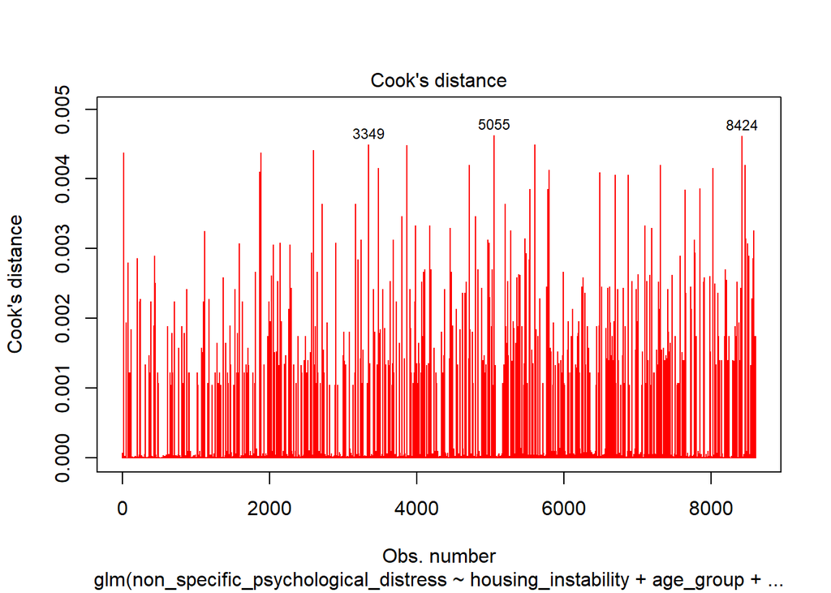

```r
# Plot Cooks's distance
plot(model2, which = 4, id.n = 3, col="red") # which = 4 gives Cook's distance calculations (see https://stat.ethz.ch/R-manual/R-patched/library/stats/html/plot.lm.html)
abline(h=1, col="red", lty=2)  # Add a threshold line
```

- **Cook’s D calculations for each observation and some other stats**

  Using threshold of cook’s distance cutoff of 1

```r
model2.data <- augment(model2) %>%
  mutate(index = 1:n())

head(model2.data)
```

```
## # A tibble: 6 × 13
##   non_specific_psychological_distress housing_instability age_group income_level
##   <fct>                               <fct>               <fct>     <fct>
## 1 No                                  No                  65+       Low Income
## 2 No                                  No                  65+       Low Income
## 3 No                                  No                  45-64     High Income
## 4 No                                  Yes                 18-29     Low Income
## 5 No                                  No                  45-64     High Income
## 6 No                                  Yes                 65+       Low Income
## # ℹ 9 more variables: employment_status <fct>, health_insurance_status <fct>,
## #   .fitted <dbl>, .resid <dbl>, .hat <dbl>, .sigma <dbl>, .cooksd <dbl>,
## #   .std.resid <dbl>, index <int>
```

```r
cutoff <- 1

Chs_model2_small <- model2.data %>% # excludes observations
  filter(.cooksd < cutoff)

nrow(Chs_model2_small)/nrow(chs_data_analysis) # check percent kept
```

```
## [1] 1
```

**Interpretation Cook’s Distances:**

Based on the cook’s distance cutoff of 1, there are no influential observations in the data. Hence, all the cases will be maintained.

  ```r
  # Various pseudo R squares, log likelihood, deviance, AIC, BIC
  blr_model_fit_stats(model2)
  ```

  ```
  ##                                Model Fit Statistics
  ## ----------------------------------------------------------------------------------
  ## Log-Lik Intercept Only:     -1905.083    Log-Lik Full Model:             -1813.410
  ## Deviance(8594):              3626.821    LR(9):                            183.344
  ##                                          Prob > LR:                          0.000
  ## MCFadden's R2                   0.048    McFadden's Adj R2:                  0.043
  ## ML (Cox-Snell) R2:              0.021    Cragg-Uhler(Nagelkerke) R2:         0.059
  ## McKelvey & Zavoina's R2:        0.095    Efron's R2:                         0.024
  ## Count R2:                       0.942    Adj Count R2:                       0.000
  ## BIC:                         3717.421    AIC:                             3646.821
  ## ----------------------------------------------------------------------------------
  ```

  ```r
  # Log-Lik: A better model fit is one with a higher Log-Lik

  # Hosmer lemeshow goodness of fit test: a significant p value indicates a bad fit
  blr_test_hosmer_lemeshow(model2)
  ```

  ```
  ##            Partition for the Hosmer & Lemeshow Test
  ## --------------------------------------------------------------
  ##                         def = 1                 def = 0
  ## Group    Total    Observed    Expected    Observed    Expected
  ## --------------------------------------------------------------
  ##   1      1403        32        35.86        1371      1367.14
  ##   2      1031        26        31.59        1005       999.41
  ##   3       189        6          5.97        183        183.03
  ##   4      1022        43        38.03        979        983.97
  ##   5       732        25        30.81        707        701.19
  ##   6       793        40        39.32        753        753.68
  ##   7       884        70        53.40        814        830.60
  ##   8       929        70        67.04        859        861.96
  ##   9       848        84        81.79        764        766.21
  ##  10       773       103        115.20       670        657.80
  ## --------------------------------------------------------------
  ##
  ##      Goodness of Fit Test
  ## ------------------------------
  ## Chi-Square    DF    Pr > ChiSq
  ## ------------------------------
  ##  10.4958      8       0.2319
  ## ------------------------------
  ```

  **Interpretation**: Model fits

  The model fits the data well, as the predictors significantly improve it compared to the intercept-only model LR(9) =183.34 , P < .001). However, the model explains only a small portion of the variance R<sup>2</sup>=0.048). The Hosmer-Lemeshow test (P=0.232) shows the predicted values align closely with the observed data, indicating the model is a good fit.
- **Compare the full model to the reduced model with the lrtest function that compares log-likelihoods**.

```r
# likelihood ratio test: compare two nested models
lrtest(model1, model2)
```

```
## Likelihood ratio test
##
## Model 1: non_specific_psychological_distress ~ housing_instability
## Model 2: non_specific_psychological_distress ~ housing_instability + age_group +
##     income_level + employment_status + health_insurance_status
##   #Df  LogLik Df  Chisq Pr(>Chisq)
## 1   2 -1866.6
## 2  10 -1813.4  8 106.44  < 2.2e-16 ***
## ---
## Signif. codes:  0 '***' 0.001 '**' 0.01 '*' 0.05 '.' 0.1 ' ' 1
```

#### Interpretation: Likelihood ratio test

Based on the likelihood ratio test, adding age group, income level, employment status, and health insurance status significantly improves the model fit compared to housing instability alone (χ2(8)=106.44, p<.001). This suggests that the additional variables contribute meaningfully to explaining non-specific psychological distress.

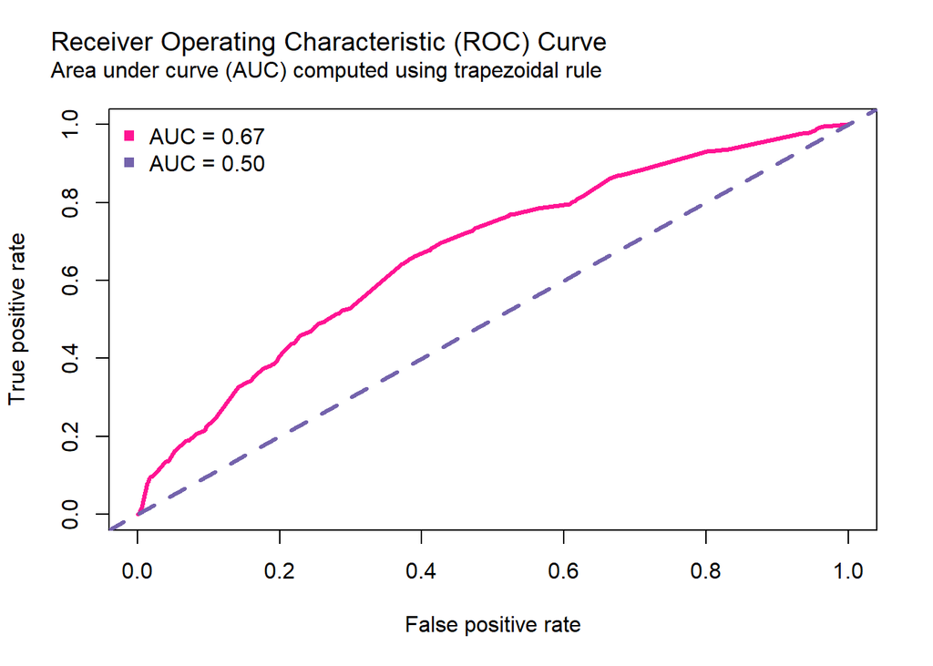

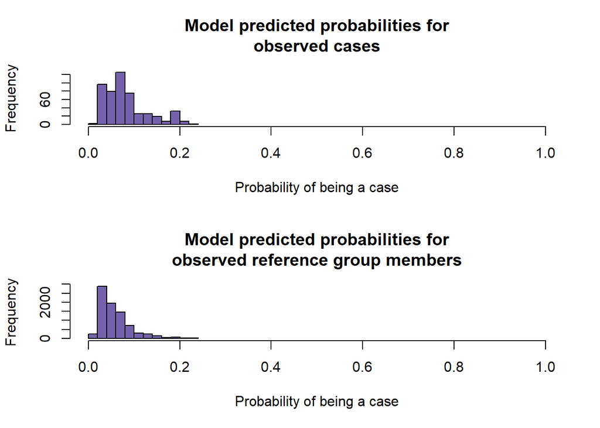

```
## $`Logistic regression model significance`
## Chi-squared        d.f.           p
##     183.344           9       <.001
##
## $`Contingency tables (model fit): frequency predicted`
##                 Number observed
## Number predicted    1    0  Sum
##              1      0    0    0
##              0    499 8105 8604
##              Sum  499 8105 8604
##
## $`Count R-squared (model fit): percent correctly predicted`
## [1] 94.20037
##
## $`Model sensitivity`
## [1] 0
##
## $`Model specificity`
## [1] 1
##
## $`Predictor odds ratios and 95% CI`
##                                             OR      2.5 %     97.5 %
## (Intercept)                         0.04174253 0.02800569 0.06102436
## housing_instabilityYes              2.26367788 1.82676518 2.79516419
## age_group30-44                      0.86993892 0.66209576 1.14705620
## age_group45-64                      0.79434443 0.61281810 1.03473015
## age_group65+                        0.46562202 0.33991983 0.63741886
## income_levelModerate Income         0.65989903 0.49746148 0.86399676
## income_levelHigh Income             0.64984660 0.51778959 0.81232166
## employment_statusUnemployed         1.63731637 1.24540743 2.13901591
## employment_statusNot in labor force 2.42988754 1.93327996 3.05454810
## health_insurance_statusYes          1.36173985 1.00818760 1.87577695
```

```r
odds.n.ends(model2, rocPlot = TRUE, predProbPlot = TRUE)
```

**interpretation**:

The ROC curve shows an AUC (Area Under the Curve) of 0.67, indicating a moderate ability of the model to discriminate between individuals with and without non-specific psychological distress. The specificity of the model is 1.00, meaning it correctly identifies all cases without psychological distress, but the sensitivity is 0.00, indicating it fails to identify cases with psychological distress. Despite the high overall accuracy of 94.2%, the model’s performance in identifying positive cases is poor, limiting its practical utility.